# Coursera Data Science Capstone Project - Shiny App for Next Word Prediction Using N-Grams

Nethika Suraweera  
September 4th, 2018

This Shiny app uses a basic n-gram model for predicting the next word based on the previous 1, 2, 3 or 4 words, using 1-grams, 2-grams, 3-grams, 4-grams and 5-grams. This is the capstone project for the Coursera Data Science Specialization done by the Johns Hopkins University in collaboration with SwiftKey.

### Summary

English text data from 3 different sources: Blogs, Twitter & News were used in this project. The data were sampled, preprocessed and tokenized using well known R-text mining packages.

A “next word prediction” model was developed by optimizing accuracy and efficiency. A simple “backoff model” was used to handle the words that may not be in the corpora. If there is no suggestion for the next word using 5-Grams (using last 4 words), then use 4-Grams, if not 3-grams, if not 2-Grams. Finally, if still not, use the highest probability 1-Gram word: “the”. The model also calculates a second guess and a third guess.

Shiny interactive app was developed and launched in Shinyapps.io. It predicts the next word, 2nd guess and 3rd guess when user enters words. Also displays the plots and data of n- grams as selected by the user.

### How Does the App Work?

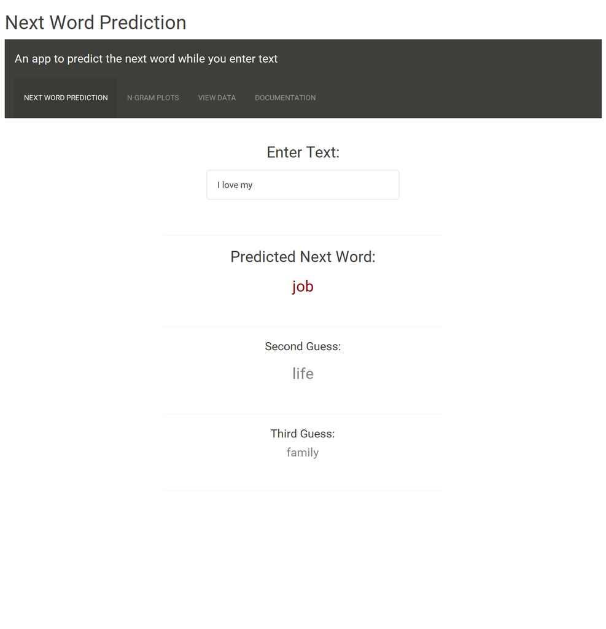

As the user enters text in the given box, the next word, 2nd guess and 3rd guess predictions are displayed. In the tab “N-GRAM PLOTS”, user can select which n-gram to view from a drop down menu and the number of terms to display with a slider bar. In the tab “VIEW DATA”, user can select which n-gram data to view from a drop down menu. The R package `DT` is used to create a data table from a R data frame. “DOCUMENTATION” tab contains a description about the app.

### Highlights

- The model performs with good accuracy. Large number of n-grams extracted and the use of a backoff model to predict the next word were helpful in building an accurate model.
- The speed of the model is excellent. It is able to predict the next word while the user is typing the text.
- R's package 'ngram' is used to tokenize the data.
- The words coming from foreign languages are handled by removing non-ascii characters.
- Profanity words, URLs, hash tags and Twitter handlers were removed from the corpora.

### Useful Links

- [Milestone Report](https://rpubs.com/nethika/milestone_report) for the first phase of the project.
- [Shiny Interactive App](https://nethika.shinyapps.io/Shiney_App_Next_Word/)
- [Github Repo](https://github.com/Nethika/shiny_app_next_word_prediction)
- [Slide Deck](http://rpubs.com/nethika/predict_next_word)
- [Coursera Data Science Specialization](https://www.coursera.org/specializations/jhu-data-science)
- Data Downloaded from: [Capstone Dataset](https://d396qusza40orc.cloudfront.net/dsscapstone/dataset/Coursera-SwiftKey.zip)